# Assignment 3

### 320200064 MIS 박사과정 강호준

### 2021.04.21

### Part 1 Comparing twot Proportions

> Consider the Bernoulli / Binomial Model with the beta prior on $\theta_1$ with parameters $a_1=0.5$ and $b_1=0.5$. Given an inspection sample of $n_1=50$ items where $y_1=7$ were found defective. Now assume that anohter manafacturer independently inspected a sample of $n_2=30$ items from its manufacturing process and found $y_2=3$ defectives. you can assume that the prior for proportion defective $\theta_2$ of the second process is also beta with parameters $a_2=0.5$ and $b_2=0.5$. Also, $\theta_1$ and $\theta_2$ are considered to be independent of each other.

#### Question 1)

> Obtain the Posterior distributions of $\theta_1$ and $\theta_2$ and using the normal approximation obtain the 95% central posterior central interval for $d=\theta_1 - \theta+2$. What is the posterior probability that $\theta_1>\theta_2$? What is the posterior probability that $d<0.02$?

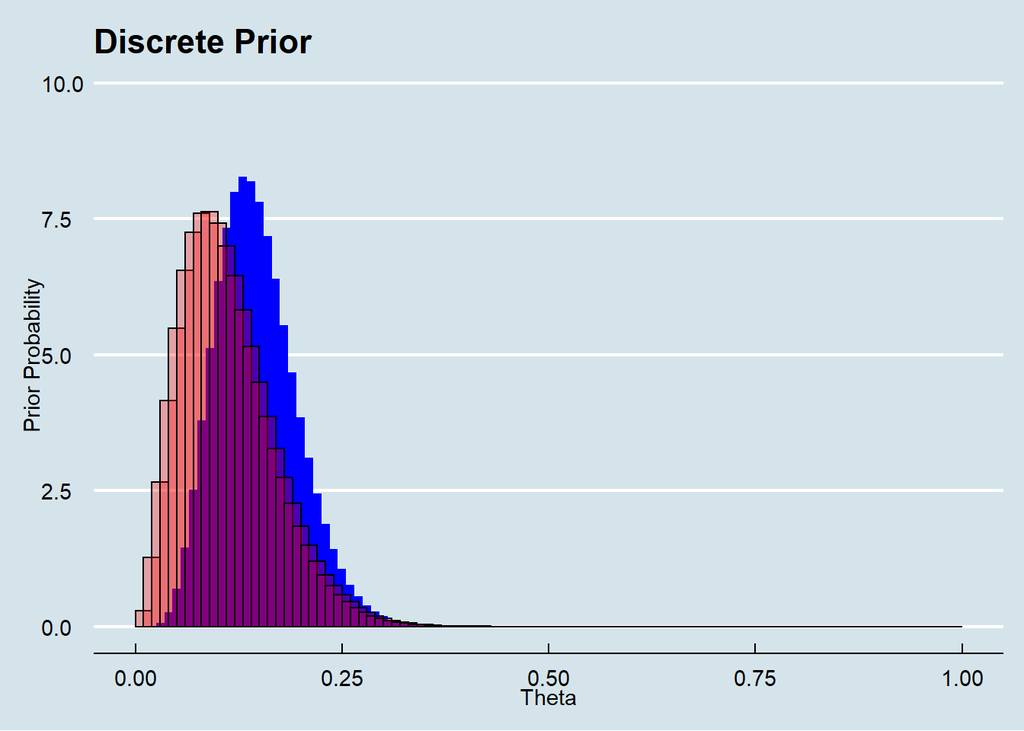

```r
#Parameter
library(ggplot2)
library(ggthemes)
y1=7
n1=50
a1=0.5
b1=0.5
theta1=seq(0.01,0.99,by=0.01)
prob1=rep(1,99)


y2=3
n2=30
a2=0.5
b2=0.5
theta2=seq(0.01,0.99,by=0.01)
prob2=rep(1,99)

#Likelihood
lik1=dbeta(theta1, shape1=a1, shape2=b1)
lik2=dbeta(theta2, shape1=a2, shape2=b2)

#Posterior Distribution
prio1r=dbeta(theta1, a1, b1)
post1=dbeta(theta1, a1+y1, b1+n1-y1)

prior2=dbeta(theta2, a2, b2)
post2=dbeta(theta2, a2+y2, b2+n2-y2)

data = data.frame(theta1, theta2, lik1, lik2, post1, post2)

ggplot(data=data, aes(theta1, post1))+
  geom_bar(stat='identity',width=0.01, fill='blue')+
  coord_cartesian(ylim=c(0,10))+
  theme_economist()+
  ggtitle("Discrete Prior")+
  xlab("Theta")+
  ylab("Prior Probability")+
  geom_bar(stat='identity', aes(x=theta2, y=post2), fill='red', color='black', alpha=0.3, width=0.02)
```

```r
#theta1-theta2
d=post1-post2
quantile(d, probs=c(0.025, 0.975))
```

```
##      2.5%     97.5%
## -4.354113  3.094292
```

```r
#theta1>theta2
sum(post1>post2)/99
```

```
## [1] 0.2222222
```

```r
#d<0.02
sum(d<0.02)/99
```

```
## [1] 0.7979798
```

#### Question 2)

> Now repeat part (1) using Monte Carlo Simulation and using R or WinBUGS with 5000 realizations in your simulation. Present the plot of the posterior distribution of $d$ and posterior box plots of $\theta_1$ and $\theta_2$ and interpret these plots.

```r
astar1 = a1 + y1
bstar1 = b1 + (n1 - y1)
astar2 = a2 + y2
bstar2 = b2 + (n2 - y2)

sim_post1=rbeta(5000,astar1, bstar1)
sim_post2=rbeta(5000,astar2, bstar2)
theta=seq(1,5000)

sim_diff=sim_post1-sim_post2
data2 = data.frame(theta, sim_post1, sim_post2, sim_diff)
head(data2)
```

```
##   theta  sim_post1  sim_post2    sim_diff
## 1     1 0.12415012 0.06226458  0.06188554
## 2     2 0.12654126 0.14937354 -0.02283228
## 3     3 0.25990972 0.06752725  0.19238247
## 4     4 0.18185316 0.07095491  0.11089825
## 5     5 0.08632462 0.10946030 -0.02313568
## 6     6 0.13071495 0.07071481  0.06000015
```

```r
#theta1-theta2
d=sim_post1-sim_post2
quantile(d, probs=c(0.025, 0.975))
```

```
##       2.5%      97.5%
## -0.1169390  0.1774428
```

```r
#theta1>theta2
sum(sim_post1>sim_post2)/5000
```

```
## [1] 0.6922
```

```r
#d<0.02
sum(d<0.02)/5000
```

```
## [1] 0.4048
```

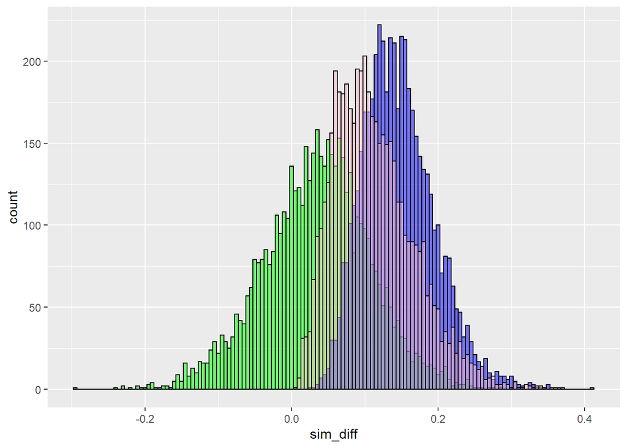

```r
ggplot(data2, aes(x=sim_diff))+
  geom_histogram(color='black',fill='green', binwidth=0.005, alpha=0.5)+
  geom_histogram(aes(x=sim_post1), color='black',fill='blue',binwidth=0.005, alpha=0.5)+
  geom_histogram(aes(x=sim_post2), color='black',fill='pink',binwidth=0.005, alpha=0.5)
```

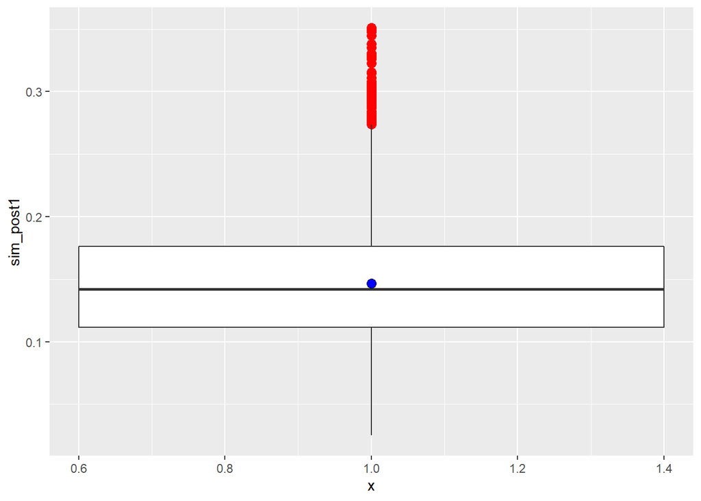

```r
ggplot(data2, aes(x=1, y=sim_post1))+
  geom_boxplot(width=0.8, outlier.size=3, outlier.shape=16, outlier.colour='red')+
  stat_summary(fun.y='mean', geom='point', shape=21, size=3, fill='blue')
```

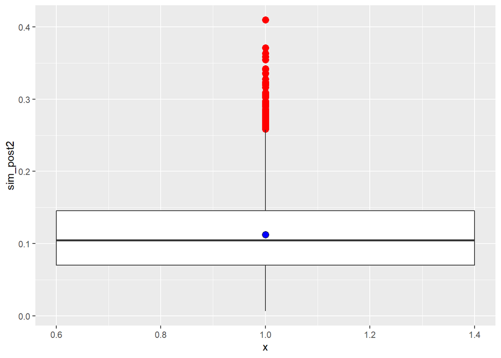

```r
ggplot(data2, aes(x=1, y=sim_post2))+
  geom_boxplot(width=0.8, outlier.size=3, outlier.shape=16, outlier.colour='red')+
  stat_summary(fun.y='mean', geom='point', shape=21, size=3, fill='blue')
```

#### Question 3

> Using the above priors obtain the Bayes factor in favor of $h_0$ to test the hypotheses $h_0 : \theta_1=theta_2$ versus $h_1:theta_1 \neq \theta_2$. In so doint under $h_0$ you can assume that common $\theta$ has a beta distribution with $a = 0.5$ and $b=0.5$ interpret the BF

```r
a=0.5
b=0.5
options(scipen=100)
o12=mean(sim_post1<sim_post2)

mat1=matrix(c(n1, y1), ncol=2)
mat2=matrix(c(n2, y2), ncol=1)

h0 = (mat1%*%mat2)*
  (gamma(a+b)/(gamma(a)*gamma(b)))*
  ((gamma(a+y1+y2)*gamma(b+n1-y1+n2-y2))/gamma(a+b+n1+n2))
h1 = (mat1%*%mat2)%*%

  ((gamma(a1+b1)/(gamma(a1)*gamma(b1)))*
  ((gamma(a1+y1)*gamma(b1+n1-y1))/gamma(a1+b1+n1)))*
  ((gamma(a2+b2)/(gamma(a2)*gamma(b2)))*
  ((gamma(a2+y2)*gamma(b2+n2-y2))/gamma(a2+b2+n2)))


BF = h0/h1
BF
```

```
##          [,1]
## [1,] 4.813099
```

#### Question 4

> Repeat part (3) by changing the inspection sample size for the second manufacturing process, but keeping the MLE of $\theta_2$ the same. More specifically use $n_2=10, 20, 30, ..., 90, 100$ and $y_2=1,2,3...,9,10$ Also create a plot of BF versus $n_2$. What is the reasoning for the observed behavior in the plot ?

```r
final=data.frame()
n2=seq(10, 100, by=10)
y2=seq(1,10,by=1)
for(i in y2){
  n1=50
  a=0.5
  b=0.5
  y1=7
  n2 = i*10
  mat1=matrix(c(n1, y1), ncol=2)
  mat2=matrix(c(n2, i), ncol=1)
  h0 = (mat1%*%mat2)*
  (gamma(a+b)/(gamma(a)*gamma(b)))*
  ((gamma(a+y1+y2)*gamma(b+n1-y1+n2-y2))/gamma(a+b+n1+n2))

  h1 = (mat1%*%mat2)%*%

  ((gamma(a1+b1)/(gamma(a1)*gamma(b1)))*
  ((gamma(a1+y1)*gamma(b1+n1-y1))/gamma(a1+b1+n1)))*
  ((gamma(a2+b2)/(gamma(a2)*gamma(b2)))*
  ((gamma(a2+y2)*gamma(b2+n2-y2))/gamma(a2+b2+n2)))

  bf=h0/h1
  dt=data.frame(h0, h1, bf)
  final=rbind(dt)




}
head(final)
```

```
##                          h0                        h1         bf
## 1 0.00000000000895879759275 0.00000000025828259180157 0.03468603
## 2 0.00000000000053816098614 0.00000000000393323743860 0.13682393
## 3 0.00000000000003638810938 0.00000000000010085224202 0.36080615
## 4 0.00000000000000273888995 0.00000000000000365785334 0.74876976
## 5 0.00000000000000022741686 0.00000000000000017235958 1.31943263
## 6 0.00000000000000002067426 0.00000000000000001003151 2.06093196
```

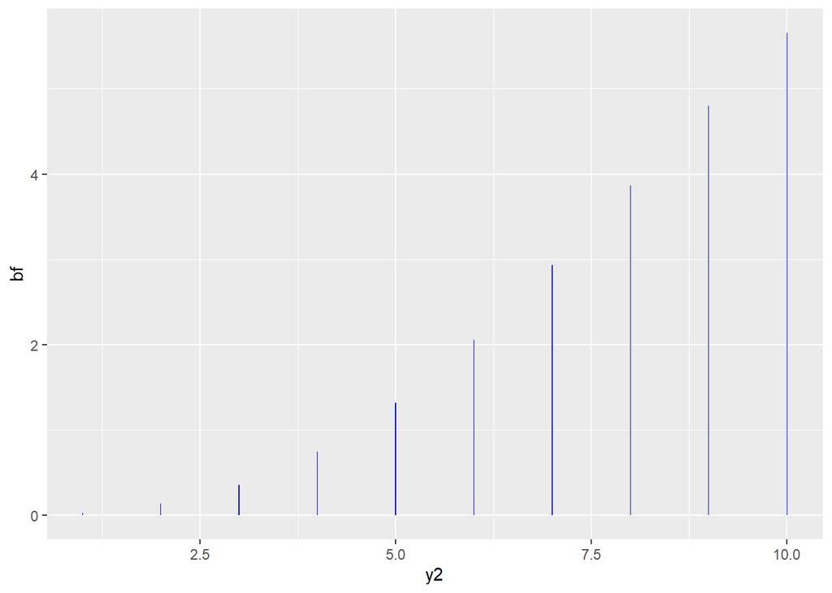

```r
ggplot(data=final, aes(y2, bf))+
  geom_bar(stat='identity',width=0.01, fill='blue')
```

#### Answer

> $h_1 = (\theta_1=\theta_2 \neq \theta_3), (\theta_1=\theta_3 \neq \theta_2), (\theta_2 = \theta_3 \neq \theta_1)$

#### Question 2

> As in Lecture Set 5, assume beta priors with parameters (1, 1) in all cases for the proportions. Using our development in Lecture Set 5, obtain the forms $p(D|h_0), p(D|h_1), p(D|h_2), p(D|h_3) and p(D|h_4)$ for general data $D$. Note that you already have the forms $p(D|h_0)$ and for $p(D|h_1)$ general $K$ in lecture set 5.
> 2. Assume that we have observed inspection data from three manufacturers. For manufacturer 1 we have a sample $n_1=20$ items where $y_1=2$ were found defective; from manufacturer 2 we have sample $n_2=20$ items with $y_2=1$ and from manufacturer 3 we have $n_3=30$ items with $y_3=1$ .

> Using the data obtain the Bayes factors $BF_01, BF_02, Bf_03$ and $BF_04$ and interpret hte results. Note that $BF_ij=p(D|h_i)/p(D|h_j)$